# DE3 Group 2 Project Brief

Author: “Rhiannon Batstone, Miles Drake, Jonathan Lau”  
Date: “14th April 2020”

# 1 Client information

**CodeClan Marketing Manager**  
Killian McAleese  
killian.mcaleese@codeclan.com

# 2 Project overview

CodeClan operates three campuses across three cities in Scotland:

- Edinburgh
- Glasgow
- Inverness

Google Analytics Console is not user friendly and is restrictive in its ability to summarise CodeClan website traffic information.

This makes it difficult to measure the impact of specific marketing campaigns on web traffic or make comparisons over time and between CodeClan sites.

## 2.1 Project objective

- Create a user-friendly product that draws upon and presents Google Analytics data
- Focusing on the Central Belt, provide an overview and comparison of user sessions relating to the three CodeClan sites
- Provide the ability to focus on specific time periods.

# 3 Product specification

[output not shown]

# 4 Product design - preliminary drafts

## 4.1 Dashboard concept

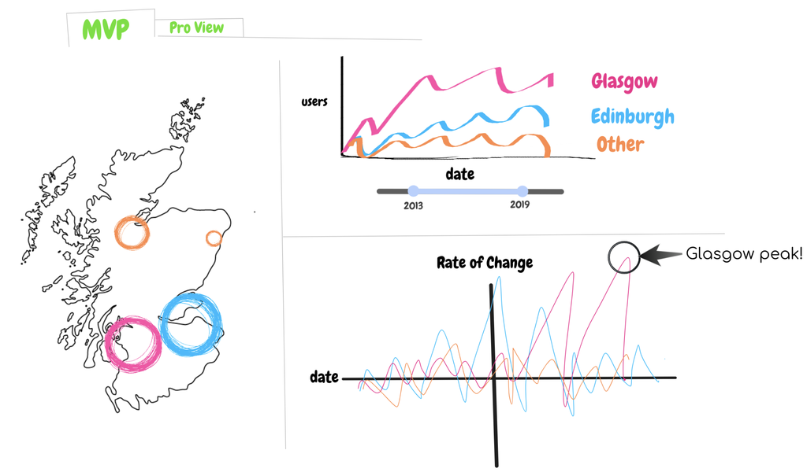

This is an early dashboard concept based upon our emphasis on readability with an intuitive layout. The final dashboard design will be a bit different and will incorporate a user-adjustable time scale.

## 4.2 Absolute user sessions chart

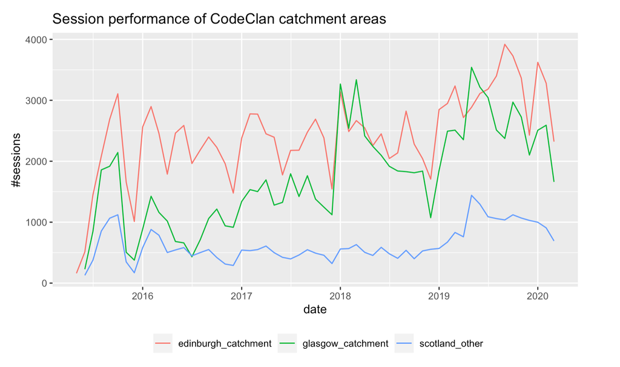

The presentation will change but this chart illustrates our ability to aggregate data from Google Analytics to draw more meaningful insight.

## 4.3 Relative user sessions chart

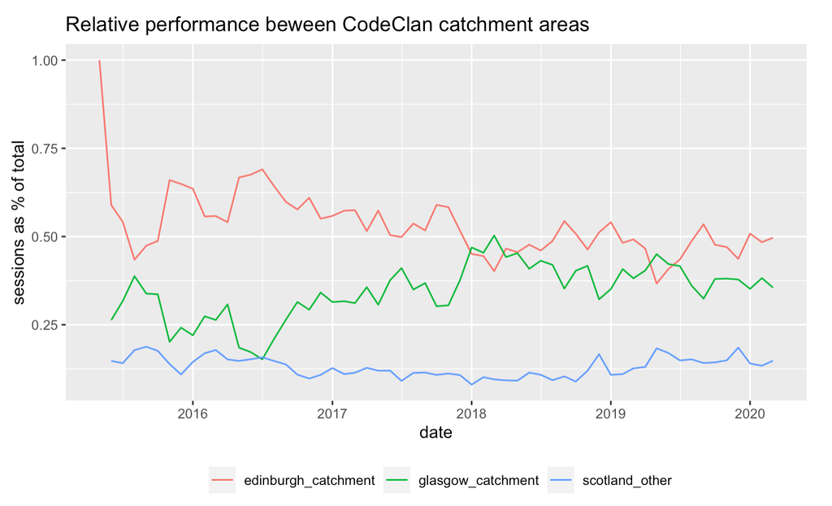

A different chart that compares user sessions as a proportion of overall Scottish web-traffic.

# 5 Additional information

- Geographically-closest area will be based upon shortest distance to the three CodeClan sites rather than having pre-defined catchment areas.
- Exact parameters TBC.

## 5.1 Caveats

- Website user location is based upon ISP location and not necessarily their physical geographic position
- However, the data analysis still provides a broad overview of CodeClan website traffic and allows for relative comparison.

## 5.2 Questions

- Are there any amendments to be made?
- Previous ad campaign details - timing, cost, nature?

## 5.3 Any amendments

Please let us know if this product brief meets your requirements and if there are any changes to be made.

Thanks!

Kind regards,  
**Rhi, Miles and Johnny**